# INN Hotels Project

## Context

A significant number of hotel bookings are called-off due to cancellations or no-shows. The typical reasons for cancellations include change of plans, scheduling conflicts, etc. This is often made easier by the option to do so free of charge or preferably at a low cost which is beneficial to hotel guests but it is a less desirable and possibly revenue-diminishing factor for hotels to deal with. Such losses are particularly high on last-minute cancellations.

The new technologies involving online booking channels have dramatically changed customers’ booking possibilities and behavior. This adds a further dimension to the challenge of how hotels handle cancellations, which are no longer limited to traditional booking and guest characteristics.

The cancellation of bookings impact a hotel on various fronts:

- Loss of resources (revenue) when the hotel cannot resell the room.
- Additional costs of distribution channels by increasing commissions or paying for publicity to help sell these rooms.
- Lowering prices last minute, so the hotel can resell a room, resulting in reducing the profit margin.
- Human resources to make arrangements for the guests.

## Objective

The increasing number of cancellations calls for a Machine Learning based solution that can help in predicting which booking is likely to be canceled. INN Hotels Group has a chain of hotels in Portugal, they are facing problems with the high number of booking cancellations and have reached out to your firm for data-driven solutions. You as a data scientist have to analyze the data provided to find which factors have a high influence on booking cancellations, build a predictive model that can predict which booking is going to be canceled in advance, and help in formulating profitable policies for cancellations and refunds.

## Data Description

The data contains the different attributes of customers' booking details. The detailed data dictionary is given below.

**Data Dictionary**

- Booking_ID: unique identifier of each booking
- no_of_adults: Number of adults
- no_of_children: Number of Children
- no_of_weekend_nights: Number of weekend nights (Saturday or Sunday) the guest stayed or booked to stay at the hotel
- no_of_week_nights: Number of week nights (Monday to Friday) the guest stayed or booked to stay at the hotel
- type_of_meal_plan: Type of meal plan booked by the customer:
  - Not Selected – No meal plan selected
  - Meal Plan 1 – Breakfast
  - Meal Plan 2 – Half board (breakfast and one other meal)
  - Meal Plan 3 – Full board (breakfast, lunch, and dinner)
- required_car_parking_space: Does the customer require a car parking space? (0 - No, 1- Yes)
- room_type_reserved: Type of room reserved by the customer. The values are ciphered (encoded) by INN Hotels.
- lead_time: Number of days between the date of booking and the arrival date
- arrival_year: Year of arrival date
- arrival_month: Month of arrival date
- arrival_date: Date of the month
- market_segment_type: Market segment designation.
- repeated_guest: Is the customer a repeated guest? (0 - No, 1- Yes)
- no_of_previous_cancellations: Number of previous bookings that were canceled by the customer prior to the current booking
- no_of_previous_bookings_not_canceled: Number of previous bookings not canceled by the customer prior to the current booking
- avg_price_per_room: Average price per day of the reservation; prices of the rooms are dynamic. (in euros)
- no_of_special_requests: Total number of special requests made by the customer (e.g. high floor, view from the room, etc)
- booking_status: Flag indicating if the booking was canceled or not.

## Importing necessary libraries and data

```python
# Importing necessary libraries
import pandas as pd  # For data manipulation
import numpy as np  # For numerical operations
import matplotlib.pyplot as plt  # For data visualization
import seaborn as sns  # For statistical data visualization
from sklearn.model_selection import train_test_split  # For splitting data into train and test sets
import statsmodels.stats.api as sms  # For statistical models and tests
from statsmodels.stats.outliers_influence import variance_inflation_factor  # For VIF calculation
import statsmodels.api as sm  # For statistical models
from statsmodels.tools.tools import add_constant  # To add a constant term to the data
from sklearn.tree import DecisionTreeClassifier  # For building decision tree models
from sklearn import tree  # For decision tree visualization
from sklearn.model_selection import GridSearchCV  # For hyperparameter tuning
from sklearn.metrics import (  # For model evaluation metrics
    f1_score,
    accuracy_score,
    recall_score,
    precision_score,
    confusion_matrix,
    roc_auc_score,
    precision_recall_curve,
    roc_curve,
    make_scorer,
)
import warnings  # For handling warnings
from statsmodels.tools.sm_exceptions import ConvergenceWarning  # For handling specific warnings

# Remove warnings to improve readability
warnings.filterwarnings("ignore", category=ConvergenceWarning)

# Set display options for pandas
pd.set_option("display.max_columns", None)  # Display all columns
pd.set_option("display.max_rows", 200)  # Display up to 200 rows
pd.set_option("display.float_format", lambda x: "%.5f" % x)  # Set floating-point precision
```

## Uploading and import files

```python
#uploading csv files
from google.colab import files
import io
try:
  uploaded
except:
  uploaded=files.upload()
```

```
Saving INNHotelsGroup (1).csv to INNHotelsGroup (1).csv
```

```python
#importing files into colab
data=pd.read_csv("INNHotelsGroup (1).csv")
#copying data to keep safe original file
df=data.copy()
```

## Data Overview

- Observations
- Sanity checks

```python
#checking top and bottom rows
df
```

|  | Booking_ID | no_of_adults | no_of_children | no_of_weekend_nights | no_of_week_nights | type_of_meal_plan | required_car_parking_space | room_type_reserved | lead_time | arrival_year | arrival_month | arrival_date | market_segment_type | repeated_guest | no_of_previous_cancellations | no_of_previous_bookings_not_canceled | avg_price_per_room | no_of_special_requests | booking_status |
| --- | --- | --- | --- | --- | --- | --- | --- | --- | --- | --- | --- | --- | --- | --- | --- | --- | --- | --- | --- |
| 0 | INN00001 | 2 | 0 | 1 | 2 | Meal Plan 1 | 0 | Room_Type 1 | 224 | 2017 | 10 | 2 | Offline | 0 | 0 | 0 | 65.00000 | 0 | Not_Canceled |
| 1 | INN00002 | 2 | 0 | 2 | 3 | Not Selected | 0 | Room_Type 1 | 5 | 2018 | 11 | 6 | Online | 0 | 0 | 0 | 106.68000 | 1 | Not_Canceled |
| 2 | INN00003 | 1 | 0 | 2 | 1 | Meal Plan 1 | 0 | Room_Type 1 | 1 | 2018 | 2 | 28 | Online | 0 | 0 | 0 | 60.00000 | 0 | Canceled |
| 3 | INN00004 | 2 | 0 | 0 | 2 | Meal Plan 1 | 0 | Room_Type 1 | 211 | 2018 | 5 | 20 | Online | 0 | 0 | 0 | 100.00000 | 0 | Canceled |
| 4 | INN00005 | 2 | 0 | 1 | 1 | Not Selected | 0 | Room_Type 1 | 48 | 2018 | 4 | 11 | Online | 0 | 0 | 0 | 94.50000 | 0 | Canceled |
| ... | ... | ... | ... | ... | ... | ... | ... | ... | ... | ... | ... | ... | ... | ... | ... | ... | ... | ... | ... |
| 36270 | INN36271 | 3 | 0 | 2 | 6 | Meal Plan 1 | 0 | Room_Type 4 | 85 | 2018 | 8 | 3 | Online | 0 | 0 | 0 | 167.80000 | 1 | Not_Canceled |
| 36271 | INN36272 | 2 | 0 | 1 | 3 | Meal Plan 1 | 0 | Room_Type 1 | 228 | 2018 | 10 | 17 | Online | 0 | 0 | 0 | 90.95000 | 2 | Canceled |
| 36272 | INN36273 | 2 | 0 | 2 | 6 | Meal Plan 1 | 0 | Room_Type 1 | 148 | 2018 | 7 | 1 | Online | 0 | 0 | 0 | 98.39000 | 2 | Not_Canceled |
| 36273 | INN36274 | 2 | 0 | 0 | 3 | Not Selected | 0 | Room_Type 1 | 63 | 2018 | 4 | 21 | Online | 0 | 0 | 0 | 94.50000 | 0 | Canceled |
| 36274 | INN36275 | 2 | 0 | 1 | 2 | Meal Plan 1 | 0 | Room_Type 1 | 207 | 2018 | 12 | 30 | Offline | 0 | 0 | 0 | 161.67000 | 0 | Not_Canceled |

36275 rows × 19 columns

#### Observations:

```python
#checking the shape of the dataframe
print("there are",df.shape[0],"rows and",df.shape[1],"columns")
```

```
there are 36275 rows and 19 columns
```

```python
#checking datatye and missing values of all feature
data.info()
```

```
<class 'pandas.core.frame.DataFrame'>
RangeIndex: 36275 entries, 0 to 36274
Data columns (total 19 columns):
 #   Column                                Non-Null Count  Dtype
---  ------                                --------------  -----
 0   Booking_ID                            36275 non-null  object
 1   no_of_adults                          36275 non-null  int64
 2   no_of_children                        36275 non-null  int64
 3   no_of_weekend_nights                  36275 non-null  int64
 4   no_of_week_nights                     36275 non-null  int64
 5   type_of_meal_plan                     36275 non-null  object
 6   required_car_parking_space            36275 non-null  int64
 7   room_type_reserved                    36275 non-null  object
 8   lead_time                             36275 non-null  int64
 9   arrival_year                          36275 non-null  int64
 10  arrival_month                         36275 non-null  int64
 11  arrival_date                          36275 non-null  int64
 12  market_segment_type                   36275 non-null  object
 13  repeated_guest                        36275 non-null  int64
 14  no_of_previous_cancellations          36275 non-null  int64
 15  no_of_previous_bookings_not_canceled  36275 non-null  int64
 16  avg_price_per_room                    36275 non-null  float64
 17  no_of_special_requests                36275 non-null  int64
 18  booking_status                        36275 non-null  object
dtypes: float64(1), int64(13), object(5)
memory usage: 5.3+ MB
```

#### Observations:

```python
#checking the duplicated value
print("there are",df.duplicated().sum(),"duplicates")
```

```
there are 0 duplicates
```

```python
# drop Booking_ID because we dont need it
df = df.drop(["Booking_ID"], axis=1)
```

```python
#checking the missing values
df.isna().sum()
```

```
no_of_adults                            0
no_of_children                          0
no_of_weekend_nights                    0
no_of_week_nights                       0
type_of_meal_plan                       0
required_car_parking_space              0
room_type_reserved                      0
lead_time                               0
arrival_year                            0
arrival_month                           0
arrival_date                            0
market_segment_type                     0
repeated_guest                          0
no_of_previous_cancellations            0
no_of_previous_bookings_not_canceled    0
avg_price_per_room                      0
no_of_special_requests                  0
booking_status                          0
dtype: int64
```

#### Observations:

- There are no missing values.

```python
#checking the statical summary
df.describe(include=np.number).T
```

|  | count | mean | std | min | 25% | 50% | 75% | max |
| --- | --- | --- | --- | --- | --- | --- | --- | --- |
| no_of_adults | 36275.00000 | 1.84496 | 0.51871 | 0.00000 | 2.00000 | 2.00000 | 2.00000 | 4.00000 |
| no_of_children | 36275.00000 | 0.10528 | 0.40265 | 0.00000 | 0.00000 | 0.00000 | 0.00000 | 10.00000 |
| no_of_weekend_nights | 36275.00000 | 0.81072 | 0.87064 | 0.00000 | 0.00000 | 1.00000 | 2.00000 | 7.00000 |
| no_of_week_nights | 36275.00000 | 2.20430 | 1.41090 | 0.00000 | 1.00000 | 2.00000 | 3.00000 | 17.00000 |
| required_car_parking_space | 36275.00000 | 0.03099 | 0.17328 | 0.00000 | 0.00000 | 0.00000 | 0.00000 | 1.00000 |
| lead_time | 36275.00000 | 85.23256 | 85.93082 | 0.00000 | 17.00000 | 57.00000 | 126.00000 | 443.00000 |
| arrival_year | 36275.00000 | 2017.82043 | 0.38384 | 2017.00000 | 2018.00000 | 2018.00000 | 2018.00000 | 2018.00000 |
| arrival_month | 36275.00000 | 7.42365 | 3.06989 | 1.00000 | 5.00000 | 8.00000 | 10.00000 | 12.00000 |
| arrival_date | 36275.00000 | 15.59700 | 8.74045 | 1.00000 | 8.00000 | 16.00000 | 23.00000 | 31.00000 |
| repeated_guest | 36275.00000 | 0.02564 | 0.15805 | 0.00000 | 0.00000 | 0.00000 | 0.00000 | 1.00000 |
| no_of_previous_cancellations | 36275.00000 | 0.02335 | 0.36833 | 0.00000 | 0.00000 | 0.00000 | 0.00000 | 13.00000 |
| no_of_previous_bookings_not_canceled | 36275.00000 | 0.15341 | 1.75417 | 0.00000 | 0.00000 | 0.00000 | 0.00000 | 58.00000 |
| avg_price_per_room | 36275.00000 | 103.42354 | 35.08942 | 0.00000 | 80.30000 | 99.45000 | 120.00000 | 540.00000 |
| no_of_special_requests | 36275.00000 | 0.61966 | 0.78624 | 0.00000 | 0.00000 | 0.00000 | 1.00000 | 5.00000 |

## Exploratory Data Analysis (EDA)

- EDA is an important part of any project involving data.
- It is important to investigate and understand the data better before building a model with it.
- A few questions have been mentioned below which will help you approach the analysis in the right manner and generate insights from the data.
- A thorough analysis of the data, in addition to the questions mentioned below, should be done.

**Leading Questions**:

1. What are the busiest months in the hotel?
2. Which market segment do most of the guests come from?
3. Hotel rates are dynamic and change according to demand and customer demographics. What are the differences in room prices in different market segments?
4. What percentage of bookings are canceled?
5. Repeating guests are the guests who stay in the hotel often and are important to brand equity. What percentage of repeating guests cancel?
6. Many guests have special requirements when booking a hotel room. Do these requirements affect booking cancellation?

```python
#copying the data
df1=df.copy()
```

## 1. What are the busiest months in the hotel?

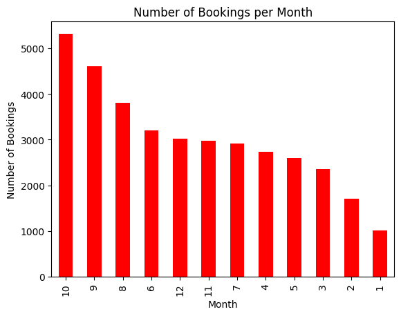

```
busiest months in the hotel is :
 arrival_month
10    5317
9     4611
8     3813
6     3203
12    3021
11    2980
7     2920
4     2736
5     2598
3     2358
2     1704
1     1014
dtype: int64
```

```python
# checking the busiest month for hotel
bookings_per_month = df1.groupby(['arrival_month']).size().sort_values(ascending=False)

bookings_per_month.plot(kind='bar',color="r")

plt.title('Number of Bookings per Month')
plt.xlabel('Month')
plt.ylabel('Number of Bookings')
plt.show()
print("busiest months in the hotel is : \n", bookings_per_month)
```

#### Observations:

- October (10) is the busiest month in the hotel, followed by September (9) and August (8).

## 2. Which market segment do most of the guests come from?

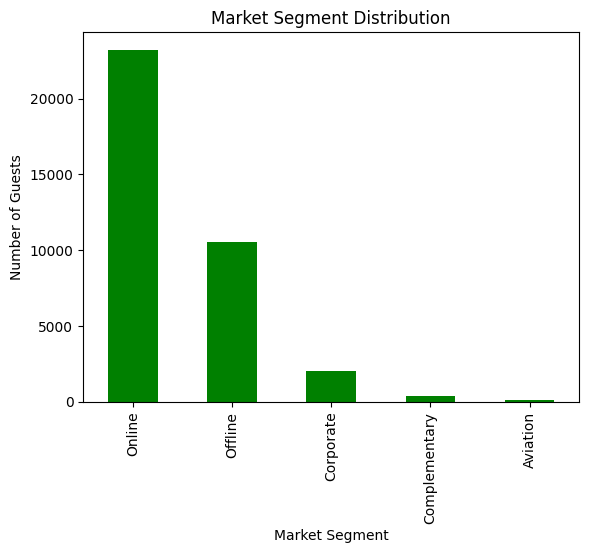

```
most of the guests come from :
 Online           23214
Offline          10528
Corporate         2017
Complementary      391
Aviation           125
Name: market_segment_type, dtype: int64
```

```python
#checking Which market segment do most of the guests come from
market_segment = df1['market_segment_type'].value_counts()

market_segment.plot(kind='bar',color="g")

plt.title('Market Segment Distribution')
plt.xlabel('Market Segment')
plt.ylabel('Number of Guests')
plt.show()
print("most of the guests come from : \n", market_segment)
```

#### Observations:

- most of the guests come from **online** (23214).
- the guests come from *offline* (10528).

## 3. Hotel rates are dynamic and change according to demand and customer demographics. What are the differences in room prices in different market segments?

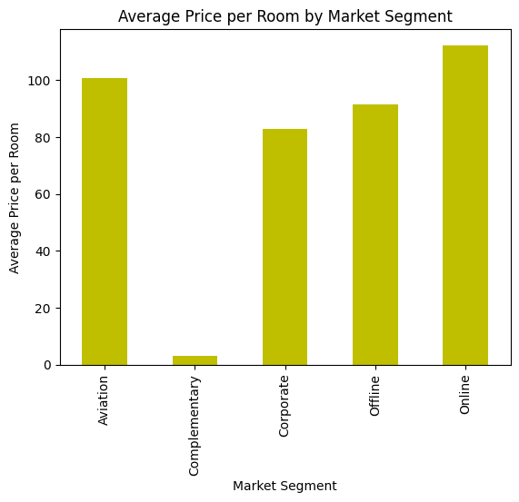

```
Average Price per Room by Market Segment:
 market_segment_type
Aviation        100.70400
Complementary     3.14176
Corporate        82.91174
Offline          91.63268
Online          112.25685
Name: avg_price_per_room, dtype: float64
```

```python
# checking average price per room in term of market segment
avg_price_per_room_by_segment = df1.groupby('market_segment_type')['avg_price_per_room'].mean()

avg_price_per_room_by_segment.plot(kind='bar',color="y")

plt.title('Average Price per Room by Market Segment')
plt.xlabel('Market Segment')
plt.ylabel('Average Price per Room')
plt.show()

print("Average Price per Room by Market Segment: \n", avg_price_per_room_by_segment)
```

#### Observations:

- online average price per room in term of market segment is around 112 euros.
- aviation average price per room in term of market segment is around 100 euros.

## 4. What percentage of bookings are canceled?

```python
# checking percentage of booking is canceled
canceled_bookings = df1[df1['booking_status'] == 'Canceled']
total_bookings = df1.shape[0]

percentage_canceled = (canceled_bookings.shape[0] / total_bookings) * 100

print(f"Percentage of Canceled Bookings: {percentage_canceled:.2f}%")
```

```
Percentage of Canceled Bookings: 32.76%
```

#### Observations:

- There are 32.76% people canceled their ticket.

## 5. Repeating guests are the guests who stay in the hotel often and are important to brand equity. What percentage of repeating guests cancel?

```python
# Checking percentage of repeating guests that cancel
repeating_guests_canceled = df1[(df1['repeated_guest'] == 1) & (df1['booking_status'] == 'Canceled')]
total_repeating_guests = df1[df1['repeated_guest'] == 1].shape[0]

percentage_repeating_canceled = (repeating_guests_canceled.shape[0] / total_repeating_guests) * 100

print(f"Percentage of Repeating Guests Canceled: {percentage_repeating_canceled:.2f}%")
```

```
Percentage of Repeating Guests Canceled: 1.72%
```

#### Observations:

- percentage of repeating guests cancel is 1.72%

## 6. Many guests have special requirements when booking a hotel room. Do these requirements affect booking cancellation?

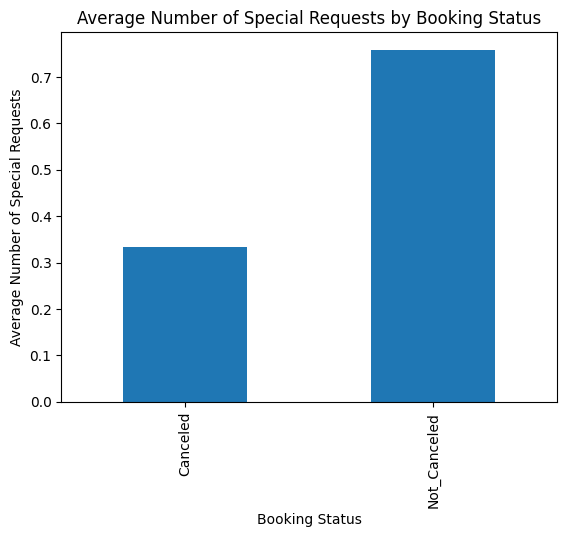

```
Average Number of Special Requests by Booking Status:
booking_status
Canceled       0.33462
Not_Canceled   0.75855
Name: no_of_special_requests, dtype: float64
```

```python
# Checking the relationship between special requests and booking cancellation
special_requests_by_cancellation = (
    df1.groupby('booking_status')['no_of_special_requests'].mean()
)

special_requests_by_cancellation.plot(kind='bar')

plt.title('Average Number of Special Requests by Booking Status')
plt.xlabel('Booking Status')
plt.ylabel('Average Number of Special Requests')
plt.show()

print(f"Average Number of Special Requests by Booking Status:\n{special_requests_by_cancellation}")
```

#### Observations:

- People who canceled their booking have average number of special requests (0.33) .
- those who did not cancel their booking have average number of special request(0.75)
- it might indicate that customers who make more special requests are less likely to cancel their bookings.

```python
#copying the data
df2=df1.copy()
```

## Data Preprocessing

- Missing value treatment (if needed)
- Feature engineering (if needed)
- Outlier detection and treatment (if needed)
- Preparing data for modeling
- Any other preprocessing steps (if needed)

```python
#checking missing values once again.
df2.isna().sum()
```

```
no_of_adults                            0
no_of_children                          0
no_of_weekend_nights                    0
no_of_week_nights                       0
type_of_meal_plan                       0
required_car_parking_space              0
room_type_reserved                      0
lead_time                               0
arrival_year                            0
arrival_month                           0
arrival_date                            0
market_segment_type                     0
repeated_guest                          0
no_of_previous_cancellations            0
no_of_previous_bookings_not_canceled    0
avg_price_per_room                      0
no_of_special_requests                  0
booking_status                          0
dtype: int64
```

#### Observations:

- There is no missing values.
- lets check outlier

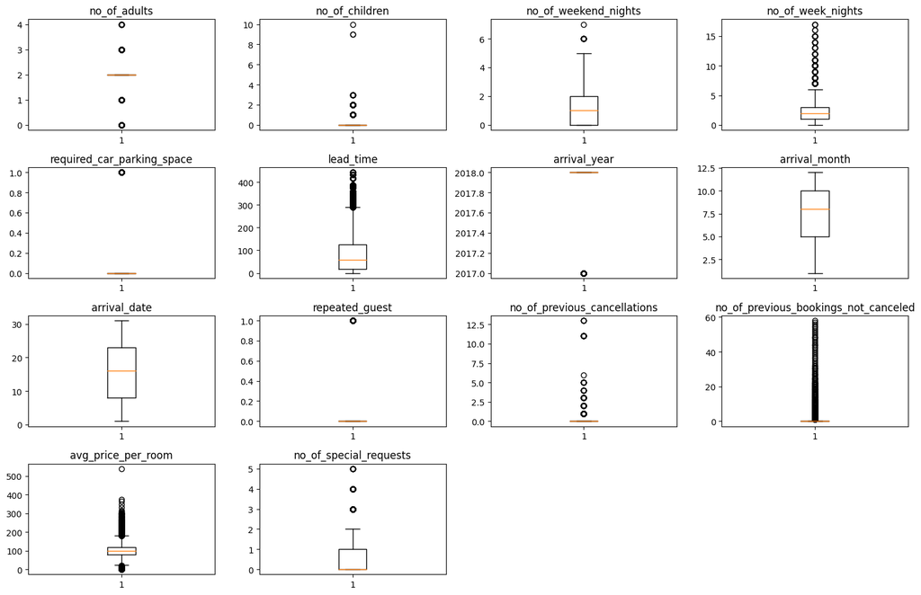

```python
# outlier detection using boxplot
numeric_columns = df2.select_dtypes(include=np.number).columns.tolist()

plt.figure(figsize=(15, 12))

for i, variable in enumerate(numeric_columns):
    plt.subplot(5, 4, i + 1)
    plt.boxplot(df2[variable], whis=1.5)
    plt.tight_layout()
    plt.title(variable)

plt.show()
```

#### Observations:

- we will keep them as they may have a valuable input.

## EDA

- It is a good idea to explore the data once again after manipulating it.

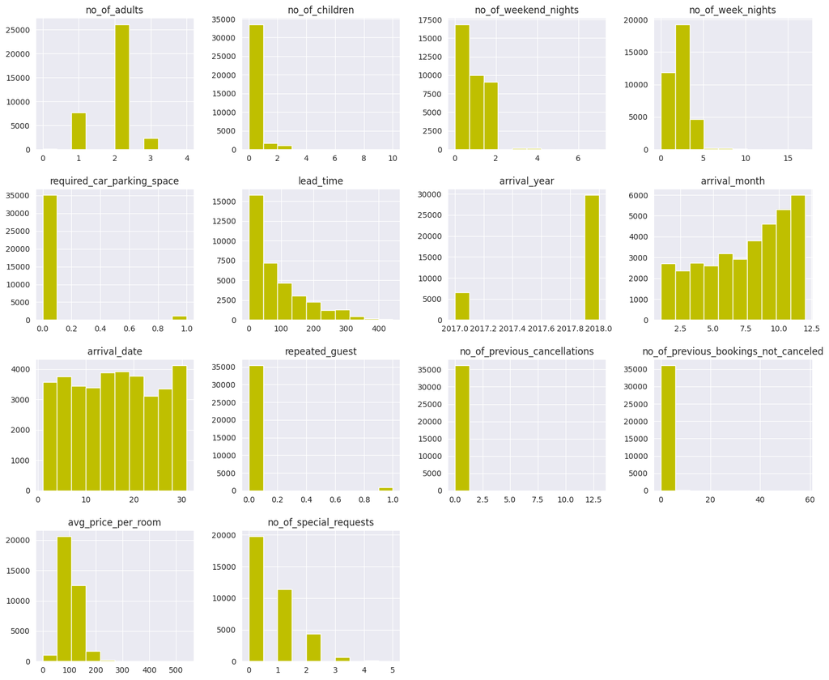

```python
# for Set seaborn style
sns.set_style("darkgrid")

# to Specify the color
hist_color = 'y'

# to Create histograms
df2.hist(figsize=(18, 15), color=hist_color)
plt.show()
```

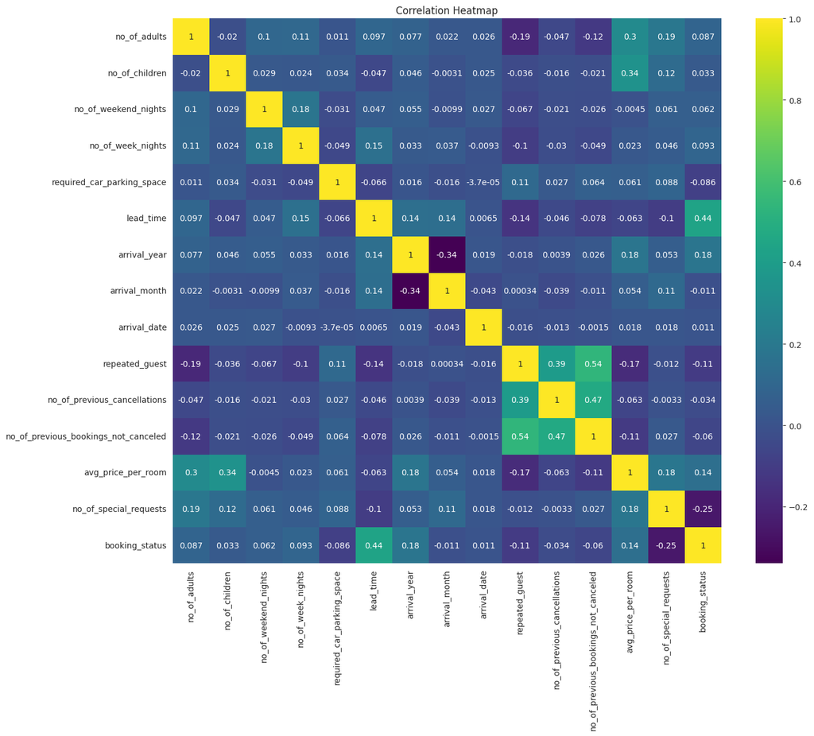

```python
#Checking the corelation with dependent variable
plt.figure(figsize=(15, 12))
sns.heatmap(df2.corr(numeric_only=True), annot=True, cmap='viridis')
plt.title('Correlation Heatmap')
plt.show()
```

#### Observations:

- More customers (adults and children) correlate positively with the average room price, reflecting increased room demand and cost.
- A negative correlation exists between average room price and repeated guests, suggesting possible loyalty benefits or discounts for returning customers.
- Positive correlations link the number of canceled and not-canceled previous bookings to repeated guests, possibly indicating customer booking patterns.

## prepareing for building model

```python
# creating dummy for booking status(dependent variable) into 0 and 1
df2["booking_status"] = df2["booking_status"].apply(
    lambda x: 1 if x == "Canceled" else 0
)
#checking shape
df2.shape
```

```
(36275, 18)
```

```python
#copying data into df3 to keep safe
df3=df2.copy()
```

## Spliting data into train and test

```python
#lets split the data traindata=70% and test data=30%
# Separate predictors (X) and target variable (Y)
X = df3.drop(["booking_status"], axis=1)
Y = df3["booking_status"]

# adding constant
X = sm.add_constant(X)

X = pd.get_dummies(X, drop_first=True)

# Splitting data in train and test sets
X_train, X_test, y_train, y_test = train_test_split(
    X, Y, test_size=0.30, random_state=1
)
```

```python
print("Shape of Training set : ", X_train.shape)
print("Shape of test set : ", X_test.shape)
print("Percentage of classes in training set:")
print(y_train.value_counts(normalize=True))
print("Percentage of classes in test set:")
print(y_test.value_counts(normalize=True))
```

```
Shape of Training set :  (25392, 28)
Shape of test set :  (10883, 28)
Percentage of classes in training set:
0   0.67064
1   0.32936
Name: booking_status, dtype: float64
Percentage of classes in test set:
0   0.67638
1   0.32362
Name: booking_status, dtype: float64
```

## Building a Logistic Regression model

```python
# fitting logistic regression model
logit = sm.Logit(y_train, X_train.astype(float))
logistic = logit.fit(disp=False)

print(logistic.summary())
```

```
                           Logit Regression Results
==============================================================================
Dep. Variable:         booking_status   No. Observations:                25392
Model:                          Logit   Df Residuals:                    25364
Method:                           MLE   Df Model:                           27
Date:                Fri, 23 Feb 2024   Pseudo R-squ.:                  0.3293
Time:                        10:31:15   Log-Likelihood:                -10793.
converged:                      False   LL-Null:                       -16091.
Covariance Type:            nonrobust   LLR p-value:                     0.000
========================================================================================================
                                           coef    std err          z      P>|z|      [0.025      0.975]
--------------------------------------------------------------------------------------------------------
const                                 -924.5923    120.817     -7.653      0.000   -1161.390    -687.795
no_of_adults                             0.1135      0.038      3.017      0.003       0.040       0.187
no_of_children                           0.1563      0.057      2.732      0.006       0.044       0.268
no_of_weekend_nights                     0.1068      0.020      5.398      0.000       0.068       0.146
no_of_week_nights                        0.0398      0.012      3.239      0.001       0.016       0.064
required_car_parking_space              -1.5939      0.138    -11.561      0.000      -1.864      -1.324
lead_time                                0.0157      0.000     58.868      0.000       0.015       0.016
arrival_year                             0.4570      0.060      7.633      0.000       0.340       0.574
arrival_month                           -0.0415      0.006     -6.418      0.000      -0.054      -0.029
arrival_date                             0.0005      0.002      0.252      0.801      -0.003       0.004
repeated_guest                          -2.3469      0.617     -3.805      0.000      -3.556      -1.138
no_of_previous_cancellations             0.2664      0.086      3.108      0.002       0.098       0.434
no_of_previous_bookings_not_canceled    -0.1727      0.153     -1.131      0.258      -0.472       0.127
avg_price_per_room                       0.0188      0.001     25.404      0.000       0.017       0.020
no_of_special_requests                  -1.4690      0.030    -48.790      0.000      -1.528      -1.410
type_of_meal_plan_Meal Plan 2            0.1768      0.067      2.654      0.008       0.046       0.307
type_of_meal_plan_Meal Plan 3           17.8379   5057.771      0.004      0.997   -9895.211    9930.887
type_of_meal_plan_Not Selected           0.2782      0.053      5.245      0.000       0.174       0.382
room_type_reserved_Room_Type 2          -0.3610      0.131     -2.761      0.006      -0.617      -0.105
room_type_reserved_Room_Type 3          -0.0009      1.310     -0.001      0.999      -2.569       2.567
room_type_reserved_Room_Type 4          -0.2821      0.053     -5.305      0.000      -0.386      -0.178
room_type_reserved_Room_Type 5          -0.7176      0.209     -3.432      0.001      -1.127      -0.308
room_type_reserved_Room_Type 6          -0.9456      0.147     -6.434      0.000      -1.234      -0.658
room_type_reserved_Room_Type 7          -1.3964      0.293     -4.767      0.000      -1.971      -0.822
market_segment_type_Complementary      -41.8798   8.42e+05  -4.98e-05      1.000   -1.65e+06    1.65e+06
market_segment_type_Corporate           -1.1935      0.266     -4.487      0.000      -1.715      -0.672
market_segment_type_Offline             -2.1955      0.255     -8.625      0.000      -2.694      -1.697
market_segment_type_Online              -0.3990      0.251     -1.588      0.112      -0.891       0.093
========================================================================================================
```

#### Observations:

- Negative coefficients mean that as the value of a specific attribute increases, the likelihood of customers canceling their booking decreases.
- Positive coefficients mean that as the value of a specific attribute increases, the likelihood of customers canceling their booking increases.
- The p-value helps us understand if a variable is significant. A smaller p-value (less than 0.05) suggests that the variable is more likely to be important.

## Model performance evaluation

```python
# defining a function to compute different metrics to check performance of a classification model built using statsmodels
def model_performance_classification_statsmodels(
    model, predictors, target, threshold=0.5
):
    """
    Function to compute different metrics to check classification model performance

    model: classifier
    predictors: independent variables
    target: dependent variable
    threshold: threshold for classifying the observation as class 1
    """

    # checking which probabilities are greater than threshold
    pred_temp = model.predict(predictors) > threshold
    # rounding off the above values to get classes
    pred = np.round(pred_temp)

    acc = accuracy_score(target, pred)  # to compute Accuracy
    recall = recall_score(target, pred)  # to compute Recall
    precision = precision_score(target, pred)  # to compute Precision
    f1 = f1_score(target, pred)  # to compute F1-score

    # creating a dataframe of metrics
    df_perf = pd.DataFrame(
        {"Accuracy": acc, "Recall": recall, "Precision": precision, "F1": f1,},
        index=[0],
    )

    return df_perf
```

```python
# defining a function to plot the confusion_matrix of a classification model


def confusion_matrix_statsmodels(model, predictors, target, threshold=0.5):
    """
    To plot the confusion_matrix with percentages

    model: classifier
    predictors: independent variables
    target: dependent variable
    threshold: threshold for classifying the observation as class 1
    """
    y_pred = model.predict(predictors) > threshold
    cm = confusion_matrix(target, y_pred)
    labels = np.asarray(
        [
            ["{0:0.0f}".format(item) + "\n{0:.2%}".format(item / cm.flatten().sum())]
            for item in cm.flatten()
        ]
    ).reshape(2, 2)

    plt.figure(figsize=(6, 4))
    sns.heatmap(cm, annot=labels, fmt="")
    plt.ylabel("True label")
    plt.xlabel("Predicted label")
```

```python
# Checking the performance
print("Training performance:")
model_performance_classification_statsmodels(logistic, X_train.astype(float), y_train)
```

```
Training performance:
```

|  | Accuracy | Recall | Precision | F1 |
| --- | --- | --- | --- | --- |
| 0 | 0.80604 | 0.63422 | 0.73975 | 0.68293 |

#### Observations:

- The model achieved an accuracy of approximately 80.6%. indicating the proportion of correctly classified.
- The recall, measuring the ability to identify positive instance, is around 63.4%.
- precision representing the accuracy of positive predictions, is 73.98%
- The F1 score, a balance between precision and recall, stands at 68.29%. but still need improvement.

## Checking Multicollinearity

- In order to make statistical inferences from a logistic regression model, it is important to ensure that there is no multicollinearity present in the data.

```python
# we will define a function to check VIF
def checking_vif(predictors):
    vif = pd.DataFrame()
    vif["feature"] = predictors.columns

    # calculating VIF for each feature
    vif["VIF"] = [
        variance_inflation_factor(predictors.values, i)
        for i in range(len(predictors.columns))
    ]
    return vif
```

```python
#checking vif score
checking_vif(X_train)
```

|  | feature | VIF |
| --- | --- | --- |
| 0 | const | 39468156.70600 |
| 1 | no_of_adults | 1.34815 |
| 2 | no_of_children | 1.97823 |
| 3 | no_of_weekend_nights | 1.06948 |
| 4 | no_of_week_nights | 1.09567 |
| 5 | required_car_parking_space | 1.03993 |
| 6 | lead_time | 1.39491 |
| 7 | arrival_year | 1.43083 |
| 8 | arrival_month | 1.27567 |
| 9 | arrival_date | 1.00674 |
| 10 | repeated_guest | 1.78352 |
| 11 | no_of_previous_cancellations | 1.39569 |
| 12 | no_of_previous_bookings_not_canceled | 1.65199 |
| 13 | avg_price_per_room | 2.05042 |
| 14 | no_of_special_requests | 1.24728 |
| 15 | type_of_meal_plan_Meal Plan 2 | 1.27185 |
| 16 | type_of_meal_plan_Meal Plan 3 | 1.02522 |
| 17 | type_of_meal_plan_Not Selected | 1.27218 |
| 18 | room_type_reserved_Room_Type 2 | 1.10144 |
| 19 | room_type_reserved_Room_Type 3 | 1.00330 |
| 20 | room_type_reserved_Room_Type 4 | 1.36152 |
| 21 | room_type_reserved_Room_Type 5 | 1.02781 |
| 22 | room_type_reserved_Room_Type 6 | 1.97307 |
| 23 | room_type_reserved_Room_Type 7 | 1.11512 |
| 24 | market_segment_type_Complementary | 4.50011 |
| 25 | market_segment_type_Corporate | 16.92844 |
| 26 | market_segment_type_Offline | 64.11392 |
| 27 | market_segment_type_Online | 71.17643 |

### Droping P-value greater then 0.05

```python
# initial list of columns
cols = X_train.columns.tolist()

# setting an initial max p-value
max_p_value = 1

while len(cols) > 0:
    # defining the train set
    x_train_aux = X_train.astype(float)[cols]

    # fitting the model
    model = sm.Logit(y_train, x_train_aux).fit(disp=False)

    # getting the p-values and the maximum p-value
    p_values = model.pvalues
    max_p_value = max(p_values)

    # name of the variable with maximum p-value
    feature_with_p_max = p_values.idxmax()

    if max_p_value > 0.05:
        cols.remove(feature_with_p_max)
    else:
        break

selected_features = cols
print(selected_features)
```

[output not shown]

```python
# now select function applying to train and test set
X_train1 = X_train[selected_features]
X_test1 = X_test[selected_features]
```

```python
# displaying logistic regression
logit1 = sm.Logit(y_train, X_train1.astype(float))
logistic1 = logit1.fit(disp=False)
print(logistic1.summary())
```

```
                           Logit Regression Results
==============================================================================
Dep. Variable:         booking_status   No. Observations:                25392
Model:                          Logit   Df Residuals:                    25370
Method:                           MLE   Df Model:                           21
Date:                Fri, 23 Feb 2024   Pseudo R-squ.:                  0.3283
Time:                        10:31:18   Log-Likelihood:                -10809.
converged:                       True   LL-Null:                       -16091.
Covariance Type:            nonrobust   LLR p-value:                     0.000
==================================================================================================
                                     coef    std err          z      P>|z|      [0.025      0.975]
--------------------------------------------------------------------------------------------------
const                           -917.2860    120.456     -7.615      0.000   -1153.376    -681.196
no_of_adults                       0.1086      0.037      2.914      0.004       0.036       0.182
no_of_children                     0.1522      0.057      2.660      0.008       0.040       0.264
no_of_weekend_nights               0.1086      0.020      5.501      0.000       0.070       0.147
no_of_week_nights                  0.0418      0.012      3.403      0.001       0.018       0.066
required_car_parking_space        -1.5943      0.138    -11.561      0.000      -1.865      -1.324
lead_time                          0.0157      0.000     59.218      0.000       0.015       0.016
arrival_year                       0.4531      0.060      7.591      0.000       0.336       0.570
arrival_month                     -0.0424      0.006     -6.568      0.000      -0.055      -0.030
repeated_guest                    -2.7365      0.557     -4.915      0.000      -3.828      -1.645
no_of_previous_cancellations       0.2289      0.077      2.983      0.003       0.078       0.379
avg_price_per_room                 0.0192      0.001     26.343      0.000       0.018       0.021
no_of_special_requests            -1.4699      0.030    -48.892      0.000      -1.529      -1.411
type_of_meal_plan_Meal Plan 2      0.1654      0.067      2.487      0.013       0.035       0.296
type_of_meal_plan_Not Selected     0.2858      0.053      5.405      0.000       0.182       0.389
room_type_reserved_Room_Type 2    -0.3560      0.131     -2.725      0.006      -0.612      -0.100
room_type_reserved_Room_Type 4    -0.2826      0.053     -5.330      0.000      -0.387      -0.179
room_type_reserved_Room_Type 5    -0.7352      0.208     -3.529      0.000      -1.143      -0.327
room_type_reserved_Room_Type 6    -0.9650      0.147     -6.572      0.000      -1.253      -0.677
room_type_reserved_Room_Type 7    -1.4312      0.293     -4.892      0.000      -2.005      -0.858
market_segment_type_Corporate     -0.7928      0.103     -7.711      0.000      -0.994      -0.591
market_segment_type_Offline       -1.7867      0.052    -34.391      0.000      -1.889      -1.685
==================================================================================================
```

```python
print("Training performance:")
model_performance_classification_statsmodels(logistic1, X_train1.astype(float), y_train.astype(float))
```

```
Training performance:
```

|  | Accuracy | Recall | Precision | F1 |
| --- | --- | --- | --- | --- |
| 0 | 0.80541 | 0.63255 | 0.73903 | 0.68166 |

#### checking the performance on the test set

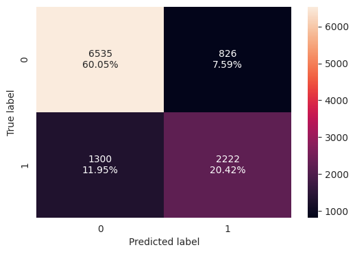

```python
# creating confusion matrix
confusion_matrix_statsmodels(logistic1, X_test1.astype(float), y_test.astype(float))
```

```python
# checking the test set performance
log_reg_model_test_perf = model_performance_classification_statsmodels(
    logistic1, X_test1.astype(float), y_test.astype(float)
)

print("Test performance:")
log_reg_model_test_perf
```

```
Test performance:
```

|  | Accuracy | Recall | Precision | F1 |
| --- | --- | --- | --- | --- |
| 0 | 0.80465 | 0.63089 | 0.72900 | 0.67641 |

#### Observations:

- The test accuracy is approximately 80.47%, with recall, precision, and F1 scores of 63.09%, 72.90%, and 67.64%, respectively. Similarly, on the training set, the accuracy is about 80.54%, with recall, precision, and F1 scores of 63.26%, 73.90%, and 68.17%. The model consistency in its predictive abilities across both training and test data.
- **the model is not overfitting or underfitting.**

#### Converting coefficients to odds

```python
# converting coefficients to odds
odds = np.exp(logistic1.params)

# finding the percentage change
perc_change_odds = (np.exp(logistic1.params) - 1) * 100

# removing limit from number of columns to display
pd.set_option("display.max_columns", None)

# adding the odds to a dataframe
pd.DataFrame({"Odds": odds, "Change_odd%": perc_change_odds}, index=X_train1.columns)
```

|  | Odds | Change_odd% |
| --- | --- | --- |
| const | 0.00000 | -100.00000 |
| no_of_adults | 1.11475 | 11.47536 |
| no_of_children | 1.16436 | 16.43601 |
| no_of_weekend_nights | 1.11475 | 11.47526 |
| no_of_week_nights | 1.04264 | 4.26363 |
| required_car_parking_space | 0.20305 | -79.69523 |
| lead_time | 1.01584 | 1.58352 |
| arrival_year | 1.57324 | 57.32351 |
| arrival_month | 0.95853 | -4.14725 |
| repeated_guest | 0.06480 | -93.52026 |
| no_of_previous_cancellations | 1.25716 | 25.71567 |
| avg_price_per_room | 1.01935 | 1.93479 |
| no_of_special_requests | 0.22994 | -77.00595 |
| type_of_meal_plan_Meal Plan 2 | 1.17992 | 17.99156 |
| type_of_meal_plan_Not Selected | 1.33089 | 33.08924 |
| room_type_reserved_Room_Type 2 | 0.70046 | -29.95389 |
| room_type_reserved_Room_Type 4 | 0.75383 | -24.61701 |
| room_type_reserved_Room_Type 5 | 0.47940 | -52.05967 |
| room_type_reserved_Room_Type 6 | 0.38099 | -61.90093 |
| room_type_reserved_Room_Type 7 | 0.23903 | -76.09669 |
| market_segment_type_Corporate | 0.45258 | -54.74162 |
| market_segment_type_Offline | 0.16750 | -83.24963 |

### Observations:

- An increase in the number of adults, children, weekend nights, and week nights generally increases the odds of booking cancellation.
- Requiring a car parking space significantly reduces the odds of booking cancellation.
- Longer lead time slightly increases the odds of booking cancellation.
- The number of special requests decreases the odds of booking cancellation.
- Customers not selecting a meal plan are more likely to cancel their bookings.
- Overall, the number of special requests has a notable impact, reducing the odds of cancellation by 77%.

#### Checking model performance on the training set

```
Training performance:
```

|  | Accuracy | Recall | Precision | F1 |
| --- | --- | --- | --- | --- |
| 0 | 0.80541 | 0.63255 | 0.73903 | 0.68166 |

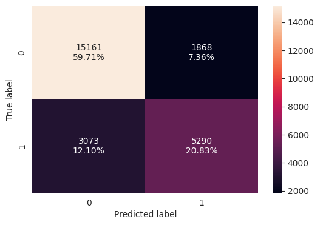

```python
# creating confusion matrix
confusion_matrix_statsmodels(logistic1, X_train1.astype(float), y_train.astype(float))
print("Training performance:")
log_reg_model_train_perf = model_performance_classification_statsmodels(
    logistic1, X_train1.astype(float), y_train.astype(float)
)
log_reg_model_train_perf
```

#### ROC-AUC

- ROC-AUC on training set

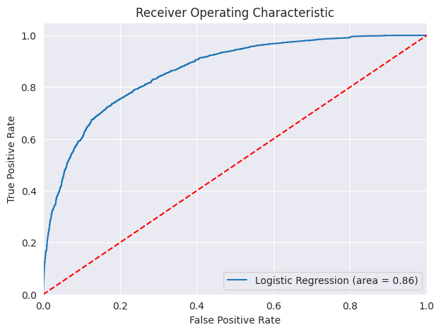

```python
from sklearn.metrics import roc_auc_score, roc_curve

# Calculating ROC AUC score on the training set
logit_roc_auc_train = roc_auc_score(y_train.astype(float), logistic1.predict(X_train1.astype(float).astype(float)))

# Calculating false positive rate, true positive rate, and thresholds for the ROC curve
fpr, tpr, thresholds = roc_curve(y_train.astype(float), logistic1.predict(X_train1.astype(float)))

# Setting up the plot figure
plt.figure(figsize=(7, 5))

# Plotting the ROC curve
plt.plot(fpr, tpr, label="Logistic Regression (area = %0.2f)" % logit_roc_auc_train)

# Plotting the diagonal line representing random guessing
plt.plot([0, 1], [0, 1], "r--")

# Setting x-axis and y-axis limits
plt.xlim([0.0, 1.0])
plt.ylim([0.0, 1.05])

# Adding labels and title to the plot
plt.xlabel("False Positive Rate")
plt.ylabel("True Positive Rate")
plt.title("Receiver Operating Characteristic")

# Adding legend to the plot
plt.legend(loc="lower right")

# Displaying the plot
plt.show()
```

#### Observations:

- ROC-AUC score of 0.86 on training is quite good.

#### Model Performance Improving:

Let's see if the recall score can be improved further, by changing the model threshold using AUC-ROC Curve

#### Optimal threshold using AUC-ROC curve

```python
# The optimal cut off would be where tpr is high and fpr is low
fpr, tpr, thresholds = roc_curve(y_train.astype(float), logistic1.predict(X_train1.astype(float)))

optimal_idx = np.argmax(tpr - fpr)
optimal_threshold_auc_roc = thresholds[optimal_idx]
print(optimal_threshold_auc_roc)
```

```
0.37104666234890077
```

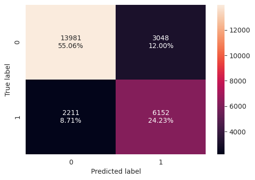

```python
# creating confusion matrix
confusion_matrix_statsmodels(
    logistic1, X_train1.astype(float), y_train.astype(float), threshold=optimal_threshold_auc_roc
)
```

```python
# checking model performance for this model
log_reg_model_train_perf_threshold_auc_roc = model_performance_classification_statsmodels(
    logistic1, X_train1.astype(float), y_train.astype(float), threshold=optimal_threshold_auc_roc
)
print("Training performance:")
log_reg_model_train_perf_threshold_auc_roc
```

```
Training performance:
```

|  | Accuracy | Recall | Precision | F1 |
| --- | --- | --- | --- | --- |
| 0 | 0.79289 | 0.73562 | 0.66870 | 0.70056 |

#### Observations:

- Recall has increased significantly as compared to the previous model.
- As we will decrease the threshold value, Recall will keep on increasing and the Precision will decrease, but this is not right, we need to choose an optimal balance between recall and precision.

##### Let's check the performance on the test set

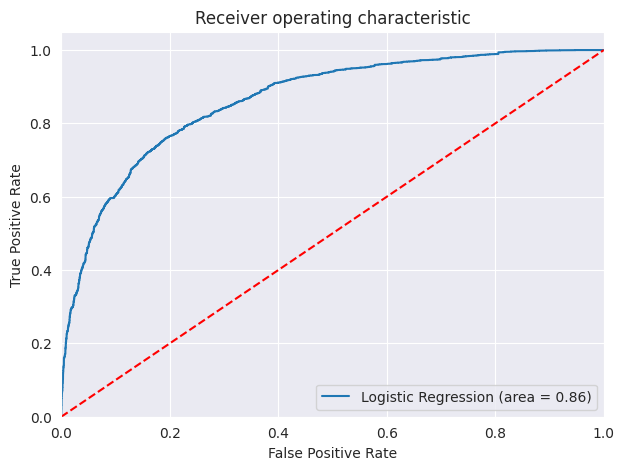

```python
#Computes the ROC-AUC (Area Under the Curve) score for the logistic regression model on the test set
logit_roc_auc_train = roc_auc_score(y_test.astype(float), logistic1.predict(X_test1.astype(float)))

#Computes the False Positive Rate (fpr), True Positive Rate (tpr), and corresponding thresholds for the ROC curve.
fpr, tpr, thresholds = roc_curve(y_test.astype(float), logistic1.predict(X_test1.astype(float)))

#Sets the figure size for the plot.
plt.figure(figsize=(7, 5))

# Plots the ROC curve, with the AUC score displayed in the legend.
plt.plot(fpr, tpr, label="Logistic Regression (area = %0.2f)" % logit_roc_auc_train)

#Plots a diagonal line representing a random classifier.
plt.plot([0, 1], [0, 1], "r--")

#Sets the x and y-axis limits,Labels the axes.
plt.xlim([0.0, 1.0])
plt.ylim([0.0, 1.05])
plt.xlabel("False Positive Rate")
plt.ylabel("True Positive Rate")
plt.title("Receiver operating characteristic")
#Displays the legend in the lower-right corner.
plt.legend(loc="lower right")
plt.show()
```

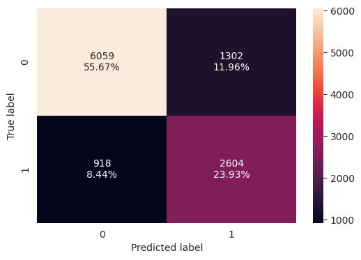

```python
# creating confusion matrix
confusion_matrix_statsmodels(logistic1, X_test1.astype(float), y_test.astype(float), threshold=optimal_threshold_auc_roc)
```

```python
# checking model performance for this model
log_reg_model_test_perf_threshold_auc_roc = model_performance_classification_statsmodels(
    logistic1, X_test1.astype(float), y_test.astype(float), threshold=optimal_threshold_auc_roc
)
print("Test performance:")
log_reg_model_test_perf_threshold_auc_roc
```

```
Test performance:
```

|  | Accuracy | Recall | Precision | F1 |
| --- | --- | --- | --- | --- |
| 0 | 0.79601 | 0.73935 | 0.66667 | 0.70113 |

###### now useing Precision-Recall curve and see if we can find out better threshold

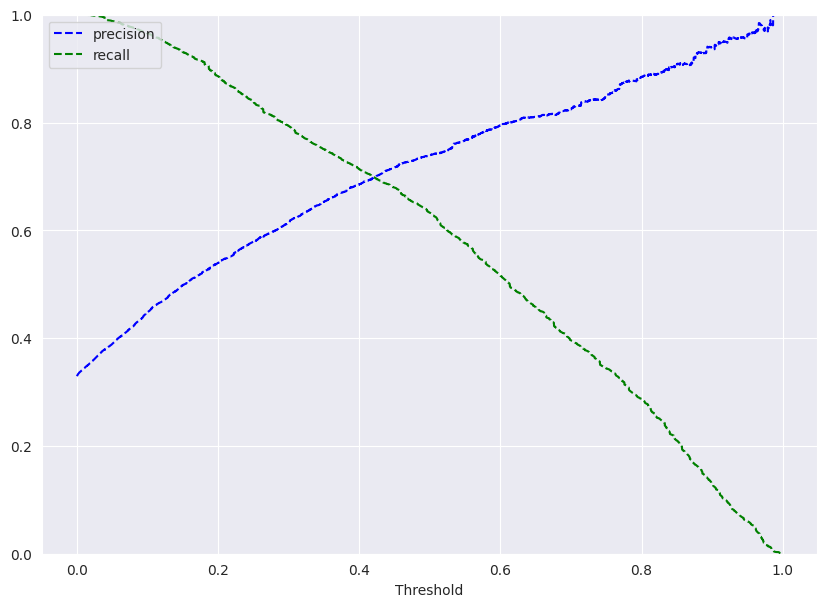

```python
# Predicts the probabilities or scores for the positive class (1) using the logistic regression model on the training set
y_scores = logistic1.predict(X_train1.astype(float))

# Computes precision, recall, and thresholds for different decision thresholds.
prec, rec, tre = precision_recall_curve(y_train.astype(float), y_scores,)


#function to plot precision and recall against decision thresholds.
def plot_prec_recall_vs_tresh(precisions, recalls, thresholds):
    plt.plot(thresholds, precisions[:-1], "b--", label="precision")#Plots precision against decision thresholds in blue dashed line.
    plt.plot(thresholds, recalls[:-1], "g--", label="recall") #Plots recall against decision thresholds in green dashed line.
    plt.xlabel("Threshold")#Labels the x-axis as "Threshold".
    plt.legend(loc="upper left")#Displays a legend in the upper-left corner.
    plt.ylim([0, 1])#Sets the y-axis limits between 0 and 1.


plt.figure(figsize=(10, 7))# Sets the figure size.
plot_prec_recall_vs_tresh(prec, rec, tre)# Calls the defined function to plot precision and recall against thresholds.
plt.show()
```

#### Observations:

- At 0.42 threshold we get a balanced precision and recall.

```python
# setting the threshold
optimal_threshold_curve = 0.42
```

#### Checking model performance on training set

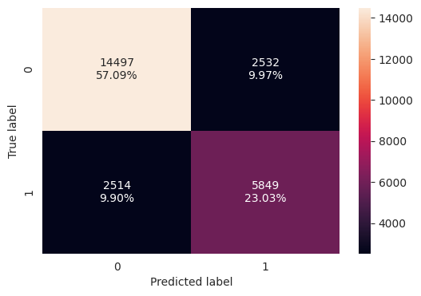

```python
# creating confusion matrix
confusion_matrix_statsmodels(logistic1, X_train1.astype(float), y_train.astype(float), threshold=optimal_threshold_curve)
```

```python
 #checking performance on the training set using a specific threshold (optimal_threshold_curve)
log_reg_model_train_perf_threshold_curve = model_performance_classification_statsmodels(
    logistic1, X_train1.astype(float), y_train.astype(float), threshold=optimal_threshold_curve
)

# Printing the training performance metrics
print("Training performance:")
log_reg_model_train_perf_threshold_curve
```

```
Training performance:
```

|  | Accuracy | Recall | Precision | F1 |
| --- | --- | --- | --- | --- |
| 0 | 0.80128 | 0.69939 | 0.69789 | 0.69864 |

#### Observations:

- Model performance has improved as compared to our initial model.
- Model has given a balanced performance in terms of precision and recall.

#### Let's check the performance on the test set

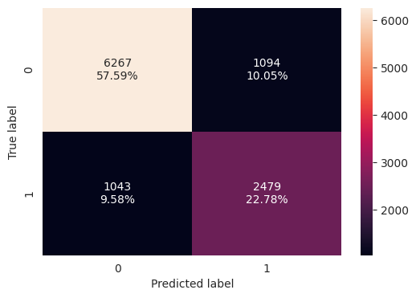

```python
# creating confusion matrix
confusion_matrix_statsmodels(logistic1, X_test1.astype(float), y_test.astype(float), threshold=optimal_threshold_curve)
```

```python
##checking performance on the test set using a specific threshold (optimal_threshold_curve)
log_reg_model_test_perf_threshold_curve = model_performance_classification_statsmodels(
    logistic1, X_test1.astype(float), y_test.astype(float), threshold=optimal_threshold_curve
)
print("Test performance:")
log_reg_model_test_perf_threshold_curve
```

```
Test performance:
```

|  | Accuracy | Recall | Precision | F1 |
| --- | --- | --- | --- | --- |
| 0 | 0.80364 | 0.70386 | 0.69381 | 0.69880 |

## Final Model Summary

###### Model performance summary

```python
# training performance comparison

models_train_comp_df = pd.concat(
    [
        log_reg_model_train_perf.T,
        log_reg_model_train_perf_threshold_auc_roc.T,
        log_reg_model_train_perf_threshold_curve.T,
    ],
    axis=1,
)
models_train_comp_df.columns = [
    "Logistic Regression-default Threshold",
    "Logistic Regression-0.37 Threshold",
    "Logistic Regression-0.42 Threshold",
]

print("Training performance comparison:")
models_train_comp_df
```

```
Training performance comparison:
```

|  | Logistic Regression-default Threshold | Logistic Regression-0.37 Threshold | Logistic Regression-0.42 Threshold |
| --- | --- | --- | --- |
| Accuracy | 0.80541 | 0.79289 | 0.80128 |
| Recall | 0.63255 | 0.73562 | 0.69939 |
| Precision | 0.73903 | 0.66870 | 0.69789 |
| F1 | 0.68166 | 0.70056 | 0.69864 |

```python
# test performance comparison

models_test_comp_df = pd.concat(
    [
        log_reg_model_test_perf.T,
        log_reg_model_test_perf_threshold_auc_roc.T,
        log_reg_model_test_perf_threshold_curve.T,
    ],
    axis=1,
)
models_test_comp_df.columns = [
    "Logistic Regression-default Threshold",
    "Logistic Regression-0.37 Threshold",
    "Logistic Regression-0.42 Threshold",
]

print("Test performance comparison:")
models_test_comp_df
```

```
Test performance comparison:
```

|  | Logistic Regression-default Threshold | Logistic Regression-0.37 Threshold | Logistic Regression-0.42 Threshold |
| --- | --- | --- | --- |
| Accuracy | 0.80465 | 0.79601 | 0.80364 |
| Recall | 0.63089 | 0.73935 | 0.70386 |
| Precision | 0.72900 | 0.66667 | 0.69381 |
| F1 | 0.67641 | 0.70113 | 0.69880 |

#### Observations:

- it is a good prediction model for the hotel to know if someone might cancel their booking. It works well on different sets of data.
- The hotel can decide how careful they want to be about predicting cancellations. They can choose to be more accurate but might miss some cancellations, or they can catch more cancellations but might make some mistakes.
- Some things we found: If the hotel doesn't have a parking space, if it's a certain month, or if the customer made special requests, there's less chance of a cancellation. But if there are more adults, children, longer stays, or higher prices, there's a higher chance of cancellation.

## Decision Tree

#### Data Preparation for modeling (Decision Tree)

```python
#copying data
df4=df3.copy()
```

```python
X = df3.drop(["booking_status"], axis=1)
Y = df3["booking_status"]

X = pd.get_dummies(X, drop_first=True)

# Splitting data in train and test sets
X_train, X_test, y_train, y_test = train_test_split(
    X, Y, test_size=0.30, random_state=1
)
```

```python
print("Shape of Training set : ", X_train.shape)
print("Shape of test set : ", X_test.shape)
print("Percentage of classes in training set:")
print(y_train.value_counts(normalize=True))
print("Percentage of classes in test set:")
print(y_test.value_counts(normalize=True))
```

```
Shape of Training set :  (25392, 27)
Shape of test set :  (10883, 27)
Percentage of classes in training set:
0   0.67064
1   0.32936
Name: booking_status, dtype: float64
Percentage of classes in test set:
0   0.67638
1   0.32362
Name: booking_status, dtype: float64
```

## Building a Decision Tree model

```python
model = DecisionTreeClassifier(random_state=1)
model.fit(X_train, y_train)
```

```
DecisionTreeClassifier(random_state=1)
```

#### First, let's create functions to calculate different metrics and confusion matrix so that we don't have to use the same code repeatedly for each model.

The model_performance_classification_sklearn function will be used to check the model performance of models. The confusion_matrix_sklearnfunction will be used to plot the confusion matrix.

```python
# defining a function to compute different metrics to check performance of a classification model built using sklearn
def model_performance_classification_sklearn(model, predictors, target):
    """
    Function to compute different metrics to check classification model performance

    model: classifier
    predictors: independent variables
    target: dependent variable
    """

    # predicting using the independent variables
    pred = model.predict(predictors)

    acc = accuracy_score(target, pred)  # to compute Accuracy
    recall = recall_score(target, pred)  # to compute Recall
    precision = precision_score(target, pred)  # to compute Precision
    f1 = f1_score(target, pred)  # to compute F1-score

    # creating a dataframe of metrics
    df_perf = pd.DataFrame(
        {"Accuracy": acc, "Recall": recall, "Precision": precision, "F1": f1,},
        index=[0],
    )

    return df_perf
```

```python
def confusion_matrix_sklearn(model, predictors, target):
    """
    To plot the confusion_matrix with percentages

    model: classifier
    predictors: independent variables
    target: dependent variable
    """
    y_pred = model.predict(predictors)
    cm = confusion_matrix(target, y_pred)
    labels = np.asarray(
        [
            ["{0:0.0f}".format(item) + "\n{0:.2%}".format(item / cm.flatten().sum())]
            for item in cm.flatten()
        ]
    ).reshape(2, 2)

    plt.figure(figsize=(6, 4))
    sns.heatmap(cm, annot=labels, fmt="")
    plt.ylabel("True label")
    plt.xlabel("Predicted label")
```

##### Checking model performance on training set

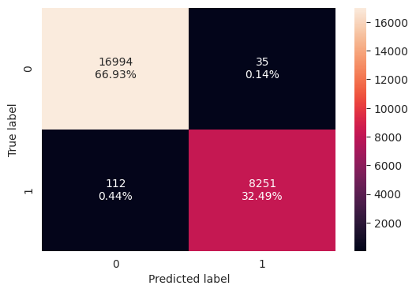

```python
#creating confusion metrix
confusion_matrix_sklearn(model, X_train, y_train)
```

```python
#decision tree performance on train set
decision_tree_perf_train = model_performance_classification_sklearn(
    model, X_train, y_train
)
decision_tree_perf_train
```

|  | Accuracy | Recall | Precision | F1 |
| --- | --- | --- | --- | --- |
| 0 | 0.99421 | 0.98661 | 0.99578 | 0.99117 |

### Checking model performance on test set

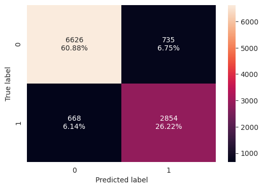

```python
#creating confusion matrix
confusion_matrix_sklearn(model, X_test, y_test)
```

```python
#checking decision tree performance on test set
decision_tree_perf_test = model_performance_classification_sklearn(
    model, X_test, y_test
)
decision_tree_perf_test
```

|  | Accuracy | Recall | Precision | F1 |
| --- | --- | --- | --- | --- |
| 0 | 0.87108 | 0.81034 | 0.79521 | 0.80270 |

#### observations:

- The decision tree model is indeed overfitting the data, which means it's too complex and has memorized the training set instead of generalizing well to new data.we need to prune the decision tree, simplifying its structure and preventing it from capturing noise in the training set. Pruning is essential for improving the model's ability to generalize and perform well on unseen data.

**Before pruning the tree let's check the important features.**

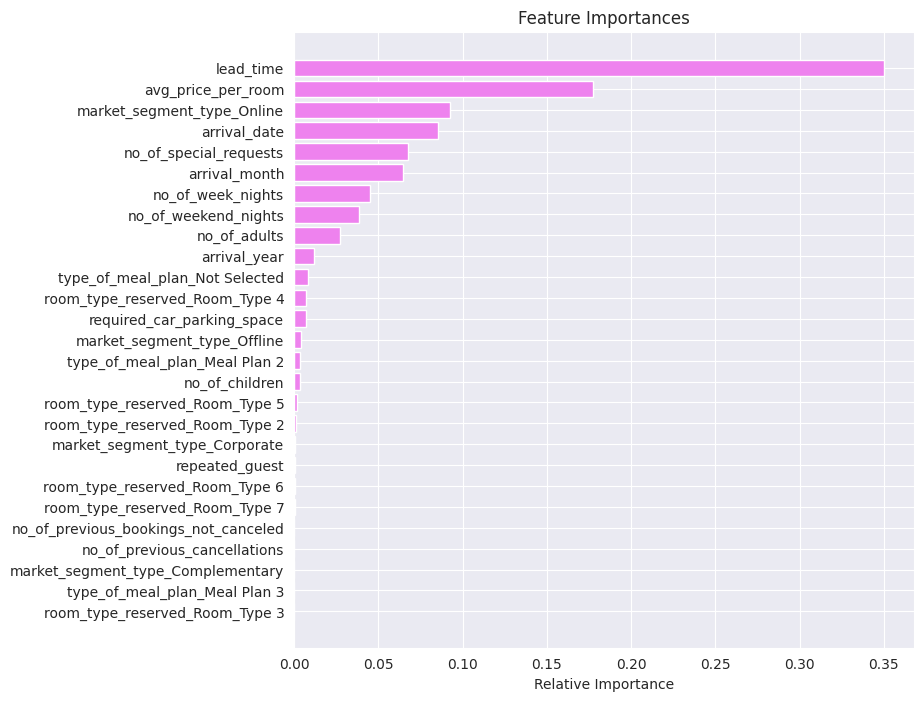

```python
# Get the list of feature names and their importances
feature_names = list(X_train.columns)
importances = model.feature_importances_

# Sort indices based on feature importances
indices = np.argsort(importances)

# Plotting the bar chart for feature importances
plt.figure(figsize=(8, 8))
plt.title("Feature Importances")
plt.barh(range(len(indices)), importances[indices], color="violet", align="center")
plt.yticks(range(len(indices)), [feature_names[i] for i in indices])
plt.xlabel("Relative Importance")
plt.show()
```

#### Observations:

- Lead time is the most important feature followed by average price per room.
- Now let's prune the tree to see if we can reduce the complexity.

## Do we need to prune the tree?

#### Pre-pruning the tree

```python
# Choose the type of classifier.
estimator = DecisionTreeClassifier(random_state=1, class_weight="balanced")

# Grid of parameters to choose from
parameters = {
    "max_depth": np.arange(2, 7, 2),
    "max_leaf_nodes": [50, 75, 150, 250],
    "min_samples_split": [10, 30, 50, 70],
}

# Type of scoring used to compare parameter combinations
acc_scorer = make_scorer(f1_score)

# Run the grid search
grid_obj = GridSearchCV(estimator, parameters, scoring=acc_scorer, cv=5)
grid_obj = grid_obj.fit(X_train, y_train)

# Set the clf to the best combination of parameters
estimator = grid_obj.best_estimator_

# Fit the best alogisticorithm to the data.
estimator.fit(X_train, y_train)
```

```
DecisionTreeClassifier(class_weight='balanced', max_depth=6, max_leaf_nodes=50,
                       min_samples_split=10, random_state=1)
```

#### Checking performance on training set

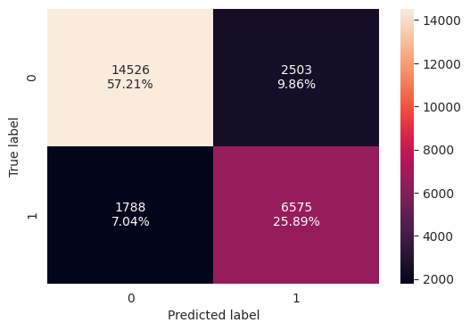

```python
# checking into confusion matrix
confusion_matrix_sklearn(estimator, X_train.astype(float), y_train.astype(float))
```

```python
#checking performanc into train set
decision_tree_tune_perf_train = model_performance_classification_sklearn(
    estimator, X_train, y_train
)
decision_tree_tune_perf_train
```

|  | Accuracy | Recall | Precision | F1 |
| --- | --- | --- | --- | --- |
| 0 | 0.83101 | 0.78620 | 0.72428 | 0.75397 |

#### Checking performance on test set

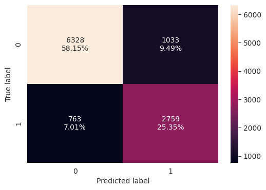

```python
# creating confusion matrix
confusion_matrix_sklearn(estimator, X_test, y_test)
```

```python
#checking the performance on test set
decision_tree_tune_perf_test = model_performance_classification_sklearn(
    estimator, X_test, y_test
)
decision_tree_tune_perf_test
```

|  | Accuracy | Recall | Precision | F1 |
| --- | --- | --- | --- | --- |
| 0 | 0.83497 | 0.78336 | 0.72758 | 0.75444 |

### Visualizing the Decision Tree

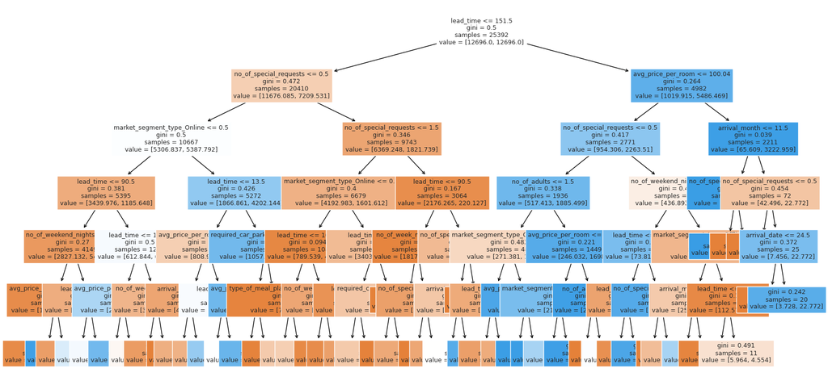

```python
plt.figure(figsize=(20, 10))
out = tree.plot_tree(
    estimator,
    feature_names=feature_names,
    filled=True,
    fontsize=9,
    node_ids=False,
    class_names=None,
)
# below code will add arrows to the decision tree split if they are missing
for o in out:
    arrow = o.arrow_patch
    if arrow is not None:
        arrow.set_edgecolor("black")
        arrow.set_linewidth(1)
plt.show()
```

```python
# Text report showing the rules of a decision tree -
print(tree.export_text(estimator, feature_names=feature_names, show_weights=True))
```

```
|--- lead_time <= 151.50
|   |--- no_of_special_requests <= 0.50
|   |   |--- market_segment_type_Online <= 0.50
|   |   |   |--- lead_time <= 90.50
|   |   |   |   |--- no_of_weekend_nights <= 0.50
|   |   |   |   |   |--- avg_price_per_room <= 196.50
|   |   |   |   |   |   |--- weights: [1736.39, 132.08] class: 0
|   |   |   |   |   |--- avg_price_per_room >  196.50
|   |   |   |   |   |   |--- weights: [0.75, 25.81] class: 1
|   |   |   |   |--- no_of_weekend_nights >  0.50
|   |   |   |   |   |--- lead_time <= 68.50
|   |   |   |   |   |   |--- weights: [960.27, 223.16] class: 0
|   |   |   |   |   |--- lead_time >  68.50
|   |   |   |   |   |   |--- weights: [129.73, 160.92] class: 1
|   |   |   |--- lead_time >  90.50
|   |   |   |   |--- lead_time <= 117.50
|   |   |   |   |   |--- avg_price_per_room <= 93.58
|   |   |   |   |   |   |--- weights: [214.72, 227.72] class: 1
|   |   |   |   |   |--- avg_price_per_room >  93.58
|   |   |   |   |   |   |--- weights: [82.76, 285.41] class: 1
|   |   |   |   |--- lead_time >  117.50
|   |   |   |   |   |--- no_of_week_nights <= 1.50
|   |   |   |   |   |   |--- weights: [87.23, 81.98] class: 0
|   |   |   |   |   |--- no_of_week_nights >  1.50
|   |   |   |   |   |   |--- weights: [228.14, 48.58] class: 0
|   |   |--- market_segment_type_Online >  0.50
|   |   |   |--- lead_time <= 13.50
|   |   |   |   |--- avg_price_per_room <= 99.44
|   |   |   |   |   |--- arrival_month <= 1.50
|   |   |   |   |   |   |--- weights: [92.45, 0.00] class: 0
|   |   |   |   |   |--- arrival_month >  1.50
|   |   |   |   |   |   |--- weights: [363.83, 132.08] class: 0
|   |   |   |   |--- avg_price_per_room >  99.44
|   |   |   |   |   |--- lead_time <= 3.50
|   |   |   |   |   |   |--- weights: [219.94, 85.01] class: 0
|   |   |   |   |   |--- lead_time >  3.50
|   |   |   |   |   |   |--- weights: [132.71, 280.85] class: 1
|   |   |   |--- lead_time >  13.50
|   |   |   |   |--- required_car_parking_space <= 0.50
|   |   |   |   |   |--- avg_price_per_room <= 71.92
```

[output cut: 93 more lines]

```
|   |   |   |   |   |   |--- weights: [5.96, 4.55] class: 0
|   |--- avg_price_per_room >  100.04
|   |   |--- arrival_month <= 11.50
|   |   |   |--- no_of_special_requests <= 2.50
|   |   |   |   |--- weights: [0.00, 3200.19] class: 1
|   |   |   |--- no_of_special_requests >  2.50
|   |   |   |   |--- weights: [23.11, 0.00] class: 0
|   |   |--- arrival_month >  11.50
|   |   |   |--- no_of_special_requests <= 0.50
|   |   |   |   |--- weights: [35.04, 0.00] class: 0
|   |   |   |--- no_of_special_requests >  0.50
|   |   |   |   |--- arrival_date <= 24.50
|   |   |   |   |   |--- weights: [3.73, 0.00] class: 0
|   |   |   |   |--- arrival_date >  24.50
|   |   |   |   |   |--- weights: [3.73, 22.77] class: 1
```

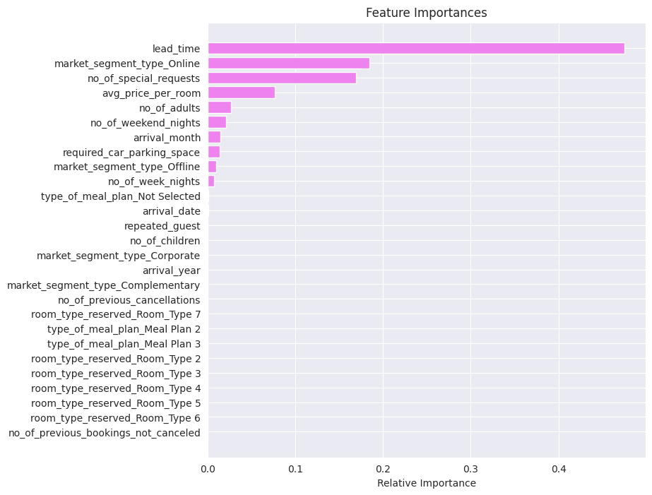

```python
# importance of features in the tree building

importances = estimator.feature_importances_
indices = np.argsort(importances)

plt.figure(figsize=(8, 8))
plt.title("Feature Importances")
plt.barh(range(len(indices)), importances[indices], color="violet", align="center")
plt.yticks(range(len(indices)), [feature_names[i] for i in indices])
plt.xlabel("Relative Importance")
plt.show()
```

**Observations for Decision Tree:**

- The decision tree rules have become simpler and more readable, indicating a better understanding of the model.
- Key features like lead time, market segment (Online), number of special requests, and average price per room are crucial for predicting cancellations.
- Important Rules:

  a. **For bookings made over 151 days before arrival:**
  - Less likely to be canceled if average price > 100 euros in December.
  - Likely to be canceled if average price ≤ 100 euros with no special request.

  b. **For bookings made under 151 days before arrival:**
  - Less likely to be canceled if there's at least 1 special request.
  - More likely to be canceled without special requests, especially if booked online.
- These rules offer insights into when cancellations are likely, providing a practical understanding for decision-making.

#### Cost Complexity Pruning

```python
# Decision tree classifier with balanced class weights
clf = DecisionTreeClassifier(random_state=1, class_weight="balanced")

# Calculate the pruning path using cost-complexity pruning
path = clf.cost_complexity_pruning_path(X_train, y_train)

# Extract alpha values and corresponding impurity values
ccp_alphas, impurities = abs(path.ccp_alphas), path.impurities
```

```python
# creating data frame for path
pd.DataFrame(path)
```

|  | ccp_alphas | impurities |
| --- | --- | --- |
| 0 | 0.00000 | 0.00838 |
| 1 | -0.00000 | 0.00838 |
| 2 | 0.00000 | 0.00838 |
| 3 | 0.00000 | 0.00838 |
| 4 | 0.00000 | 0.00838 |
| ... | ... | ... |
| 1837 | 0.00890 | 0.32806 |
| 1838 | 0.00980 | 0.33786 |
| 1839 | 0.01272 | 0.35058 |
| 1840 | 0.03412 | 0.41882 |
| 1841 | 0.08118 | 0.50000 |

1842 rows × 2 columns

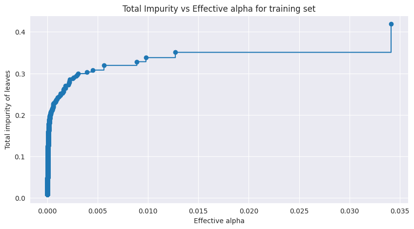

```python
# Plotting the total impurity vs effective alpha on training set
fig, ax = plt.subplots(figsize=(10, 5))
ax.plot(ccp_alphas[:-1], impurities[:-1], marker="o", drawstyle="steps-post")
ax.set_xlabel("Effective alpha")
ax.set_ylabel("Total impurity of leaves")
ax.set_title("Total Impurity vs Effective alpha for training set")
plt.show()
```

**Next, we train a decision tree using effective alphas. The last value in `ccp_alphas` is the alpha value that prunes the whole tree, leaving the tree, `clfs[-1]`, with one node.**

```python
# Creating a list to store decision tree models for different alpha values
clfs = []

# Looping through different alpha values and creating decision tree models
for ccp_alpha in ccp_alphas:
    clf = DecisionTreeClassifier(
        random_state=1, ccp_alpha=ccp_alpha, class_weight="balanced"
    )
    clf.fit(X_train, y_train)
    clfs.append(clf)

# Printing the number of nodes in the last tree and its corresponding alpha value
print(
    "Number of nodes in the last tree is: {} with ccp_alpha: {}".format(
        clfs[-1].tree_.node_count, ccp_alphas[-1]
    )
)
```

```
Number of nodes in the last tree is: 1 with ccp_alpha: 0.08117914389136943
```

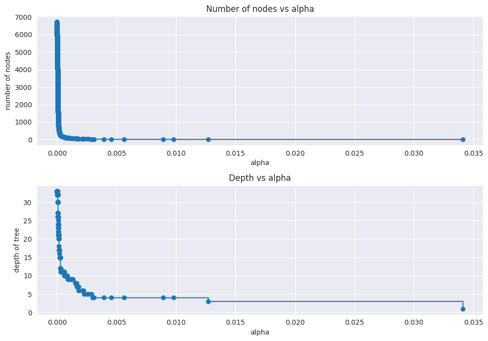

```python
# Removing the last decision tree model and corresponding alpha value
clfs = clfs[:-1]
ccp_alphas = ccp_alphas[:-1]

# Extracting number of nodes and depth for each decision tree model
node_counts = [clf.tree_.node_count for clf in clfs]
depth = [clf.tree_.max_depth for clf in clfs]

# Creating subplots to visualize the relationship between alpha, number of nodes, and depth
fig, ax = plt.subplots(2, 1, figsize=(10, 7))

# Plotting Number of nodes vs alpha
ax[0].plot(ccp_alphas, node_counts, marker="o", drawstyle="steps-post")
ax[0].set_xlabel("alpha")
ax[0].set_ylabel("number of nodes")
ax[0].set_title("Number of nodes vs alpha")

# Plotting Depth vs alpha
ax[1].plot(ccp_alphas, depth, marker="o", drawstyle="steps-post")
ax[1].set_xlabel("alpha")
ax[1].set_ylabel("depth of tree")
ax[1].set_title("Depth vs alpha")

# Adjusting layout for better visualization
fig.tight_layout()
```

### F1 Score vs alpha for training and testing sets

```python
# Calculate F1 score for each decision tree model on the training set
f1_train = []
for clf in clfs:
    pred_train = clf.predict(X_train)
    values_train = f1_score(y_train, pred_train)
    f1_train.append(values_train)

# Calculate F1 score for each decision tree model on the test set
f1_test = []
for clf in clfs:
    pred_test = clf.predict(X_test)
    values_test = f1_score(y_test, pred_test)
    f1_test.append(values_test)
```

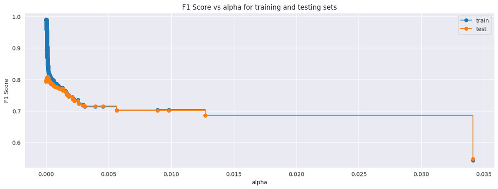

```python
## Plotting F1 Score vs alpha for training and testing sets
fig, ax = plt.subplots(figsize=(15, 5))
ax.set_xlabel("alpha")
ax.set_ylabel("F1 Score")
ax.set_title("F1 Score vs alpha for training and testing sets")
ax.plot(ccp_alphas, f1_train, marker="o", label="train", drawstyle="steps-post")
ax.plot(ccp_alphas, f1_test, marker="o", label="test", drawstyle="steps-post")
ax.legend()
plt.show()
```

```python
# Finding the best model based on F1 Score on the test set
index_best_model = np.argmax(f1_test)
best_model = clfs[index_best_model]
print(best_model)
```

```
DecisionTreeClassifier(ccp_alpha=0.0001226763315516701, class_weight='balanced',
                       random_state=1)
```

#### Checking performance on training set

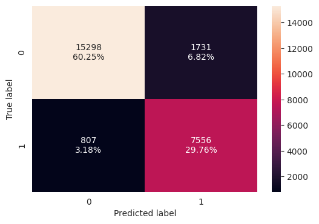

```python
# Evaluating the confusion matrix for the best model on the training set
confusion_matrix_sklearn(best_model, X_train, y_train)
```

```python
# Evaluating the performance of the best decision tree model on the training set
decision_tree_post_perf_train = model_performance_classification_sklearn(
    best_model, X_train, y_train
)
```

#### Checking performance on test set

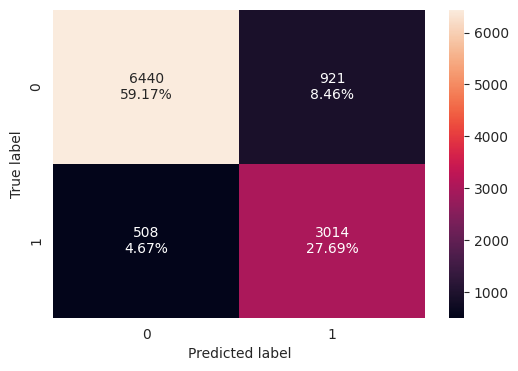

```python
# Evaluating the performance of the best decision tree model on the test set
confusion_matrix_test = confusion_matrix_sklearn(best_model, X_test, y_test)
```

```python
# Evaluating the performance of the best decision tree model on the test set
decision_tree_post_test = model_performance_classification_sklearn(best_model, X_test, y_test)
decision_tree_post_test
```

|  | Accuracy | Recall | Precision | F1 |
| --- | --- | --- | --- | --- |
| 0 | 0.86869 | 0.85576 | 0.76595 | 0.80837 |

#### Observations

- After post pruning the decision tree the performance has generalized on training and test set.
- We are getting high recall and this model but difference between recall and precision has increased.

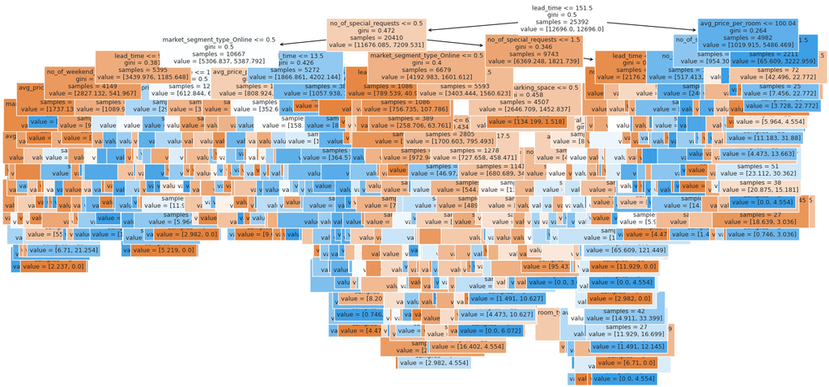

```python
#ploting decision tree
plt.figure(figsize=(20, 10))

out = tree.plot_tree(
    best_model,
    feature_names=feature_names,
    filled=True,
    fontsize=9,
    node_ids=False,
    class_names=None,
)
for o in out:
    arrow = o.arrow_patch
    if arrow is not None:
        arrow.set_edgecolor("black")
        arrow.set_linewidth(1)
plt.show()
```

```python
# Text report showing the rules of a decision tree -

print(tree.export_text(best_model, feature_names=feature_names, show_weights=True))
```

```
|--- lead_time <= 151.50
|   |--- no_of_special_requests <= 0.50
|   |   |--- market_segment_type_Online <= 0.50
|   |   |   |--- lead_time <= 90.50
|   |   |   |   |--- no_of_weekend_nights <= 0.50
|   |   |   |   |   |--- avg_price_per_room <= 196.50
|   |   |   |   |   |   |--- market_segment_type_Offline <= 0.50
|   |   |   |   |   |   |   |--- lead_time <= 16.50
|   |   |   |   |   |   |   |   |--- avg_price_per_room <= 68.50
|   |   |   |   |   |   |   |   |   |--- weights: [207.26, 10.63] class: 0
|   |   |   |   |   |   |   |   |--- avg_price_per_room >  68.50
|   |   |   |   |   |   |   |   |   |--- arrival_date <= 29.50
|   |   |   |   |   |   |   |   |   |   |--- no_of_adults <= 1.50
|   |   |   |   |   |   |   |   |   |   |   |--- truncated branch of depth 2
|   |   |   |   |   |   |   |   |   |   |--- no_of_adults >  1.50
|   |   |   |   |   |   |   |   |   |   |   |--- truncated branch of depth 5
|   |   |   |   |   |   |   |   |   |--- arrival_date >  29.50
|   |   |   |   |   |   |   |   |   |   |--- weights: [2.24, 7.59] class: 1
|   |   |   |   |   |   |   |--- lead_time >  16.50
|   |   |   |   |   |   |   |   |--- avg_price_per_room <= 135.00
|   |   |   |   |   |   |   |   |   |--- arrival_month <= 11.50
|   |   |   |   |   |   |   |   |   |   |--- repeated_guest <= 0.50
|   |   |   |   |   |   |   |   |   |   |   |--- truncated branch of depth 4
|   |   |   |   |   |   |   |   |   |   |--- repeated_guest >  0.50
|   |   |   |   |   |   |   |   |   |   |   |--- weights: [11.18, 0.00] class: 0
|   |   |   |   |   |   |   |   |   |--- arrival_month >  11.50
|   |   |   |   |   |   |   |   |   |   |--- weights: [21.62, 0.00] class: 0
|   |   |   |   |   |   |   |   |--- avg_price_per_room >  135.00
|   |   |   |   |   |   |   |   |   |--- weights: [0.00, 12.14] class: 1
|   |   |   |   |   |   |--- market_segment_type_Offline >  0.50
|   |   |   |   |   |   |   |--- weights: [1199.59, 0.00] class: 0
|   |   |   |   |   |--- avg_price_per_room >  196.50
|   |   |   |   |   |   |--- weights: [0.75, 25.81] class: 1
|   |   |   |   |--- no_of_weekend_nights >  0.50
|   |   |   |   |   |--- lead_time <= 68.50
|   |   |   |   |   |   |--- arrival_month <= 9.50
|   |   |   |   |   |   |   |--- avg_price_per_room <= 63.29
|   |   |   |   |   |   |   |   |--- arrival_date <= 20.50
|   |   |   |   |   |   |   |   |   |--- type_of_meal_plan_Not Selected <= 0.50
|   |   |   |   |   |   |   |   |   |   |--- weights: [41.75, 0.00] class: 0
```

[output cut: 651 more lines]

```
|   |   |   |   |   |   |--- weights: [5.96, 4.55] class: 0
|   |--- avg_price_per_room >  100.04
|   |   |--- arrival_month <= 11.50
|   |   |   |--- no_of_special_requests <= 2.50
|   |   |   |   |--- weights: [0.00, 3200.19] class: 1
|   |   |   |--- no_of_special_requests >  2.50
|   |   |   |   |--- weights: [23.11, 0.00] class: 0
|   |   |--- arrival_month >  11.50
|   |   |   |--- no_of_special_requests <= 0.50
|   |   |   |   |--- weights: [35.04, 0.00] class: 0
|   |   |   |--- no_of_special_requests >  0.50
|   |   |   |   |--- arrival_date <= 24.50
|   |   |   |   |   |--- weights: [3.73, 0.00] class: 0
|   |   |   |   |--- arrival_date >  24.50
|   |   |   |   |   |--- weights: [3.73, 22.77] class: 1
```

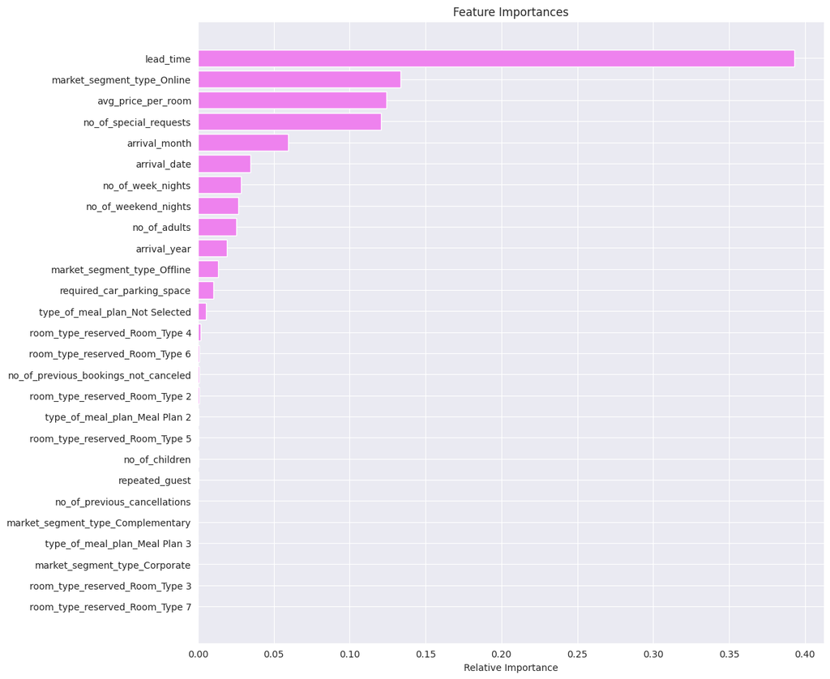

```python
# Plotting the feature importances
importances = best_model.feature_importances_
indices = np.argsort(importances)

plt.figure(figsize=(12, 12))
plt.title("Feature Importances")
plt.barh(range(len(indices)), importances[indices], color="violet", align="center")
plt.yticks(range(len(indices)), [feature_names[i] for i in indices])
plt.xlabel("Relative Importance")
plt.show()
```

## Model Performance Comparison and Conclusions

### Comparing Decision Tree models

```python
# training performance comparison

models_train_comp_df = pd.concat(
    [
        decision_tree_perf_train.T,
        decision_tree_tune_perf_train.T,
        decision_tree_post_perf_train.T,
    ],
    axis=1,
)
models_train_comp_df.columns = [
    "Decision Tree sklearn",
    "Decision Tree (Pre-Pruning)",
    "Decision Tree (Post-Pruning)",
]
print("Training performance comparison:")
models_train_comp_df
```

```
Training performance comparison:
```

|  | Decision Tree sklearn | Decision Tree (Pre-Pruning) | Decision Tree (Post-Pruning) |
| --- | --- | --- | --- |
| Accuracy | 0.99421 | 0.83101 | 0.90005 |
| Recall | 0.98661 | 0.78620 | 0.90350 |
| Precision | 0.99578 | 0.72428 | 0.81361 |
| F1 | 0.99117 | 0.75397 | 0.85620 |

```python
# testing performance comparison

models_test_comp_df = pd.concat(
    [
        decision_tree_perf_test.T,
        decision_tree_tune_perf_test.T,
        decision_tree_post_test.T,
    ],
    axis=1,
)
models_test_comp_df.columns = [
    "Decision Tree sklearn",
    "Decision Tree (Pre-Pruning)",
    "Decision Tree (Post-Pruning)",
]
print("Test set performance comparison:")
models_test_comp_df
```

```
Test set performance comparison:
```

|  | Decision Tree sklearn | Decision Tree (Pre-Pruning) | Decision Tree (Post-Pruning) |
| --- | --- | --- | --- |
| Accuracy | 0.87108 | 0.83497 | 0.86869 |
| Recall | 0.81034 | 0.78336 | 0.85576 |
| Precision | 0.79521 | 0.72758 | 0.76595 |
| F1 | 0.80270 | 0.75444 | 0.80837 |

**Observation:**

- The default decision tree model overfits the training data.
- The pre-pruned decision tree provides a balanced performance with generalization.
- Post-pruned decision tree shows a high F1 score but with imbalanced precision and recall.
- The pre-pruned decision tree is recommended for a balanced approach between resources and brand equity.

## Actionable Insights and Recommendations

## **Insights:**

- The Decision Tree model shows better performance compared to the Logistic Regression model when applied to the dataset.
- Lead Time, Number of Special Requests, and Average Price per Room are identified as significant factors influencing both models.
- Lead Time and Average Price per Room are positively associated with booking cancellations. This suggests that as lead time and room prices increase, the likelihood of cancellations also increases.
- The Number of Special Requests has a negative relationship, indicating that a higher number of special requests is linked to a lower likelihood of cancellations.

## **Business Recommendations:**

**Pay Attention to Lead Time and Special Requests:**

- Make sure to talk promptly with customers who have specific requests and booked within 151 days of their arrival.
- Send reminders and ask customers to confirm their plans before they arrive.

**Check and Update Cancellation Rules:**

- Make the cancellation rules stricter for more expensive bookings with special requests.
- Keep the cancellation rules the same for all types of customers.
- Clearly tell customers about refunds and fees if they need to cancel.

**Set a Maximum Stay Limit:**

- Tell customers they can only stay for up to 5 days, and encourage them to book again for longer stays.
- Be more flexible for business and aviation customers.

**Use Resources Smartly in Busy Months:**

- Hire more people during December and January when more guests are staying.
- Find Out Why Many Cancel in October and September:
- Figure out why so many people cancel during these months.

**Talk to Customers After They Book:**

- Chat with customers after they book to show that you care.
- Share information about local places to make their stay better.

**Make Repeat Customers Happier:**

- Create a rewards program for customers who come back.
- Give discounts and special services to make them want to keep coming back.
- Customers who come back more are good for the business and make it look good.